# NYC Taxicab Analysis

The data covers green taxicab trips during March 2020. In the analysis below, parts 1-4 consist of data exploration, parts 5-6 consist of tip percentage modelling, and part 7 provides geospatial visualizations about taxi dropoffs.

## Part 1

The code chunk below imports trip data from the NYC TLC, imports demographic information by taxi zone, and merges the demographic information to the taxi ride dataset. I assume we will want to include demographic information about the pickup (PU) and dropoff (DO) zones, so I merge the demographic information on the main dataset twice. The merged dataset representing trips in March 2020 has 223,496 rows.

```python
# Package imports and notebook settings
import pandas as pd
import matplotlib.pyplot as plt
import datetime as dt
import geopandas
import numpy as np
from sklearn.model_selection import train_test_split
from sklearn.ensemble import GradientBoostingRegressor
from sklearn.metrics import r2_score, mean_absolute_error

import warnings
with warnings.catch_warnings():
    warnings.simplefilter("ignore")

%matplotlib inline
pd.set_option('display.max_columns', 500)
pd.set_option('display.max_rows', 100)
```

```python
# Read in taxicab and demographic data
taxi_rides = pd.read_parquet("https://s3.amazonaws.com/nyc-tlc/trip+data/green_tripdata_2020-03.parquet")
demographic_info = pd.read_csv("data/raw/taxi_zone_demographics.csv")
demographic_info.drop(columns = ["Unnamed: 0"], axis = 1, inplace = True)

# Merge taxi ride and demographic data./
    # We will merge twice, first to include the demographic information of the taximeter engage zone,
    # and second to include the demographic information of the taximeter disengage zone.
departure_zone = demographic_info.copy()
departure_zone.columns = [col + "_PU" for col in departure_zone.columns]
departure_zone.reset_index(drop = True, inplace = True)

arrival_zone = demographic_info.copy()
arrival_zone.columns = [col + "_DO" for col in arrival_zone.columns]
arrival_zone.reset_index(drop = True, inplace = True)

taxi_rides_merged = pd.merge(left = taxi_rides, right = departure_zone, how = "left", left_on = "PULocationID", right_on = "Taxi zone_PU")
taxi_rides_merged = pd.merge(left = taxi_rides_merged, right = arrival_zone, how = "left", left_on = "DOLocationID", right_on = "Taxi zone_DO")

# Print out the rows and columns of each dataframe
taxi_rides_merged.shape
```

```
(223496, 38)
```

## Part 2

Below, I visualize the histogram of trip distances (in miles). The majority (75%) of trips are under 5 miles long. Some outliers exist, including a trip of 140,000 miles (I am guessing that this record is an error). Because the vast majority of trips are much shorter than the maximum value, I present a second histogram with a narrower x-range to better understand how trip distances are distributed for short trips.

```
count    223496.000000
mean          7.085787
std         606.897871
min           0.000000
25%           1.060000
50%           1.980000
75%           4.180000
max      141874.710000
Name: trip_distance, dtype: float64
```

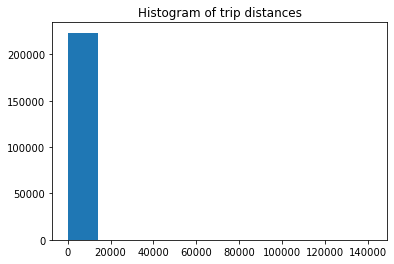

```python
# First histogram without any additional configuration - looks like there are a few outliers in the data.
plt.hist(x = taxi_rides_merged["trip_distance"])
plt.title("Histogram of trip distances")

# What is the distribution of the trip_distance variable?
taxi_rides_merged["trip_distance"].describe()
```

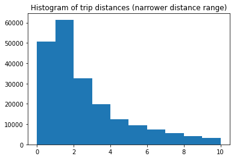

```python
# Second histogram with a narrower range - max 10 miles - which will provide more granular information on trip distances
plt.hist(x = taxi_rides_merged["trip_distance"], range = (0, 10))
plt.title("Histogram of trip distances (narrower distance range)")
```

## Part 3

The code below describes trips by hour and day of the week. Most pickups and dropoffs occur on Mondays (day = 0). Most pickups occur from 3pm-5pm, and most dropoffs occur from 4pm-6pm. This result makes sense, as we might expect for most taxi rides to occur during evening rush hour/early evening. Looking at the summary stastics, the hour 4pm and day of week Wednesday (day = 2) both have the highest average trip distances for both pickups and dropoffs.

```python
# Observe statistics by the pickup datetime
taxi_rides_merged["lpep_pickup_hour"] = taxi_rides_merged["lpep_pickup_datetime"].apply(lambda x: x.hour)
taxi_rides_merged["lpep_pickup_day_of_wk"] = taxi_rides_merged["lpep_pickup_datetime"].apply(lambda x: x.day_of_week)
```

```python
print("Statistics by pickup hour")
taxi_rides_merged.groupby("lpep_pickup_hour")["trip_distance"].describe()
```

```
Statistics by pickup hour
```

| lpep_pickup_hour | count | mean | std | min | 25% | 50% | 75% | max |
| --- | --- | --- | --- | --- | --- | --- | --- | --- |
| 0 | 4528.0 | 3.104121 | 3.711998 | 0.0 | 1.00 | 1.830 | 3.7200 | 37.10 |
| 1 | 3025.0 | 2.933623 | 3.642941 | 0.0 | 0.95 | 1.700 | 3.5300 | 36.00 |
| 2 | 1823.0 | 3.070274 | 3.936064 | 0.0 | 0.92 | 1.750 | 3.5000 | 35.24 |
| 3 | 1964.0 | 3.440575 | 4.049000 | 0.0 | 1.00 | 2.020 | 4.4200 | 40.53 |
| 4 | 2142.0 | 4.269043 | 5.078269 | 0.0 | 1.12 | 2.300 | 5.6150 | 32.69 |
| 5 | 2276.0 | 5.764363 | 5.576786 | 0.0 | 1.49 | 3.685 | 8.6000 | 33.21 |
| 6 | 4473.0 | 6.228348 | 5.967487 | 0.0 | 1.56 | 4.010 | 9.5900 | 50.10 |
| 7 | 8409.0 | 4.249302 | 4.653413 | 0.0 | 1.20 | 2.440 | 5.6800 | 52.80 |
| 8 | 11762.0 | 13.444563 | 987.687412 | 0.0 | 1.08 | 2.050 | 4.5000 | 106704.67 |
| 9 | 13040.0 | 5.505600 | 228.196087 | 0.0 | 1.06 | 2.050 | 4.3100 | 26057.72 |
| 10 | 12887.0 | 3.544716 | 4.157795 | 0.0 | 1.03 | 2.040 | 4.3650 | 48.63 |
| 11 | 12549.0 | 8.287084 | 522.794050 | 0.0 | 1.05 | 2.090 | 4.5000 | 58566.22 |
| 12 | 12612.0 | 3.673715 | 4.350831 | 0.0 | 1.06 | 2.080 | 4.5000 | 44.84 |
| 13 | 12614.0 | 5.908698 | 248.412103 | 0.0 | 1.09 | 2.140 | 4.5600 | 27899.12 |
| 14 | 13817.0 | 12.845994 | 884.476193 | 0.0 | 1.07 | 2.030 | 4.2300 | 99989.95 |
| 15 | 14514.0 | 13.254135 | 1175.360762 | 0.0 | 1.06 | 1.970 | 4.1000 | 141603.07 |
| 16 | 15287.0 | 20.667522 | 1497.332352 | 0.0 | 1.05 | 1.970 | 4.2800 | 141874.71 |
| 17 | 15614.0 | 3.161164 | 3.779822 | 0.0 | 1.05 | 1.865 | 3.6100 | 34.68 |
| 18 | 14836.0 | 4.381814 | 171.655423 | 0.0 | 1.03 | 1.770 | 3.4000 | 20906.67 |
| 19 | 12605.0 | 2.980082 | 3.597167 | 0.0 | 1.01 | 1.750 | 3.3500 | 40.53 |
| 20 | 10752.0 | 3.095785 | 3.815873 | 0.0 | 1.00 | 1.780 | 3.4600 | 32.24 |
| 21 | 8718.0 | 3.210849 | 4.030502 | 0.0 | 1.01 | 1.800 | 3.6500 | 31.00 |
| 22 | 7306.0 | 5.985887 | 229.589554 | 0.0 | 1.02 | 1.890 | 3.7675 | 19624.52 |
| 23 | 5943.0 | 3.245305 | 3.854393 | 0.0 | 1.02 | 1.890 | 3.8650 | 35.99 |

```python
print("Statistics by pickup day of week")
taxi_rides_merged.groupby("lpep_pickup_day_of_wk")["trip_distance"].describe()
```

```
Statistics by pickup day of week
```

| lpep_pickup_day_of_wk | count | mean | std | min | 25% | 50% | 75% | max |
| --- | --- | --- | --- | --- | --- | --- | --- | --- |
| 0 | 35563.0 | 7.714183 | 648.592860 | 0.0 | 1.06 | 2.000 | 4.32 | 118949.08 |
| 1 | 34959.0 | 7.178979 | 581.535547 | 0.0 | 1.06 | 1.970 | 4.23 | 106704.67 |
| 2 | 33223.0 | 12.128488 | 1099.690526 | 0.0 | 1.07 | 2.020 | 4.40 | 141874.71 |
| 3 | 32979.0 | 6.077956 | 352.974406 | 0.0 | 1.05 | 1.990 | 4.23 | 58566.22 |
| 4 | 32146.0 | 4.257650 | 121.494281 | 0.0 | 1.02 | 1.895 | 3.92 | 19624.52 |
| 5 | 24836.0 | 7.420842 | 634.468459 | 0.0 | 1.04 | 1.930 | 3.98 | 99989.95 |
| 6 | 29790.0 | 4.490622 | 161.677952 | 0.0 | 1.09 | 2.060 | 4.16 | 27899.12 |

```python
# Observe statistics by the dropoff datetime
taxi_rides_merged["lpep_dropoff_hour"] = taxi_rides_merged["lpep_dropoff_datetime"].apply(lambda x: x.hour)
taxi_rides_merged["lpep_dropoff_day_of_wk"] = taxi_rides_merged["lpep_dropoff_datetime"].apply(lambda x: x.day_of_week)
```

```python
print("Statistics by dropoff hour")
taxi_rides_merged.groupby("lpep_dropoff_hour")["trip_distance"].describe()
```

```
Statistics by dropoff hour
```

| lpep_dropoff_hour | count | mean | std | min | 25% | 50% | 75% | max |
| --- | --- | --- | --- | --- | --- | --- | --- | --- |
| 0 | 4976.0 | 3.260004 | 3.885175 | 0.0 | 1.0200 | 1.900 | 3.9100 | 37.10 |
| 1 | 3189.0 | 3.136068 | 3.854210 | 0.0 | 0.9900 | 1.780 | 3.8000 | 36.15 |
| 2 | 1956.0 | 3.120148 | 3.903779 | 0.0 | 0.9475 | 1.800 | 3.6525 | 29.59 |
| 3 | 1904.0 | 3.239821 | 4.076159 | 0.0 | 0.9600 | 1.890 | 3.9525 | 40.53 |
| 4 | 2099.0 | 3.676589 | 4.075362 | 0.0 | 1.0750 | 2.180 | 4.8950 | 29.66 |
| 5 | 1999.0 | 5.190305 | 5.396873 | 0.0 | 1.4500 | 3.230 | 7.1400 | 32.69 |
| 6 | 3438.0 | 5.531576 | 5.510260 | 0.0 | 1.4225 | 3.365 | 8.2800 | 33.21 |
| 7 | 7308.0 | 4.394481 | 4.895161 | 0.0 | 1.1900 | 2.370 | 5.8600 | 32.25 |
| 8 | 11067.0 | 4.472784 | 89.767848 | 0.0 | 1.0600 | 2.000 | 4.5550 | 9437.08 |
| 9 | 13102.0 | 13.593322 | 959.560962 | 0.0 | 1.0500 | 2.020 | 4.2575 | 106704.67 |
| 10 | 13118.0 | 3.589350 | 4.117997 | 0.0 | 1.0600 | 2.100 | 4.4400 | 36.49 |
| 11 | 12571.0 | 8.251832 | 522.335715 | 0.0 | 1.0450 | 2.060 | 4.4600 | 58566.22 |
| 12 | 12561.0 | 3.615207 | 4.286877 | 0.0 | 1.0400 | 2.050 | 4.4900 | 45.80 |
| 13 | 12583.0 | 5.964762 | 248.718812 | 0.0 | 1.1000 | 2.150 | 4.6400 | 27899.12 |
| 14 | 13243.0 | 5.664724 | 247.640124 | 0.0 | 1.0600 | 2.000 | 4.1700 | 28497.34 |
| 15 | 14242.0 | 10.382005 | 837.840607 | 0.0 | 1.0400 | 1.950 | 3.9000 | 99989.95 |
| 16 | 15043.0 | 20.852737 | 1507.730296 | 0.0 | 1.0400 | 1.930 | 4.1700 | 141603.07 |
| 17 | 15915.0 | 12.276310 | 1124.589930 | 0.0 | 1.0700 | 1.920 | 3.8700 | 141874.71 |
| 18 | 15607.0 | 4.572670 | 167.370697 | 0.0 | 1.0600 | 1.860 | 3.6300 | 20906.67 |
| 19 | 13261.0 | 3.084475 | 3.724977 | 0.0 | 1.0300 | 1.800 | 3.4600 | 33.76 |
| 20 | 11197.0 | 3.131764 | 3.807031 | 0.0 | 1.0200 | 1.820 | 3.5500 | 39.44 |
| 21 | 9057.0 | 3.273274 | 4.058266 | 0.0 | 1.0100 | 1.830 | 3.7600 | 47.52 |
| 22 | 7721.0 | 5.952070 | 223.338892 | 0.0 | 1.0500 | 1.940 | 3.9000 | 19624.52 |
| 23 | 6339.0 | 3.495952 | 4.210589 | 0.0 | 1.0600 | 1.960 | 4.1000 | 31.09 |

```python
print("Statistics by dropoff day of week")
taxi_rides_merged.groupby("lpep_dropoff_day_of_wk")["trip_distance"].describe()
```

```
Statistics by dropoff day of week
```

| lpep_dropoff_day_of_wk | count | mean | std | min | 25% | 50% | 75% | max |
| --- | --- | --- | --- | --- | --- | --- | --- | --- |
| 0 | 35566.0 | 7.707064 | 648.565493 | 0.0 | 1.06 | 2.00 | 4.31 | 118949.08 |
| 1 | 34967.0 | 7.182101 | 581.469005 | 0.0 | 1.06 | 1.98 | 4.24 | 106704.67 |
| 2 | 33211.0 | 12.135557 | 1099.889189 | 0.0 | 1.07 | 2.02 | 4.40 | 141874.71 |
| 3 | 32995.0 | 6.077887 | 352.888783 | 0.0 | 1.06 | 1.99 | 4.24 | 58566.22 |
| 4 | 32066.0 | 4.255602 | 121.645606 | 0.0 | 1.02 | 1.89 | 3.91 | 19624.52 |
| 5 | 24829.0 | 7.410930 | 634.557840 | 0.0 | 1.04 | 1.93 | 3.96 | 99989.95 |
| 6 | 29862.0 | 4.499339 | 161.483316 | 0.0 | 1.09 | 2.07 | 4.18 | 27899.12 |

## Part 4

I was curious about whether airport trips declined sharply when the pandemic began. The last histogram visualizes dropoffs by day. Most of the dropoffs occured on March 5, and I observe a sharp decline in airport dropoffs after March 20.

```python
airports = [132, 138, 1]
airport_trips = taxi_rides_merged.loc[(taxi_rides_merged["PULocationID"].isin(airports)) | (taxi_rides_merged["DOLocationID"].isin(airports)) ]
print(f"{airport_trips.shape[0]} trips began or ended at an airport.")
```

```
2716 trips began or ended at an airport.
```

```python
airport_trips["fare_amount"].describe()
```

```
count    2716.000000
mean       25.804488
std        17.575991
min         0.000000
25%        12.500000
50%        20.000000
75%        33.955000
max       140.000000
Name: fare_amount, dtype: float64
```

```python
print(f"The average fare for airport trips was ${np.round(airport_trips['fare_amount'].mean())}. By contrast, across all trips, the average fare was ${np.round(taxi_rides_merged['fare_amount'].mean())}.")
```

```
The average fare for airport trips was $26.0. By contrast, across all trips, the average fare was $14.0.
```

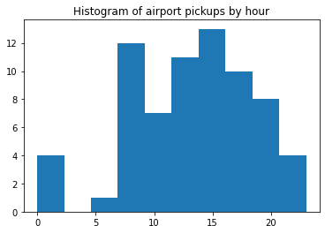

```python
# Visualize pickups by hour
airport_pickups = taxi_rides_merged.loc[taxi_rides_merged["PULocationID"].isin(airports)]
plt.hist(airport_pickups["lpep_pickup_hour"])
plt.title("Histogram of airport pickups by hour")
```

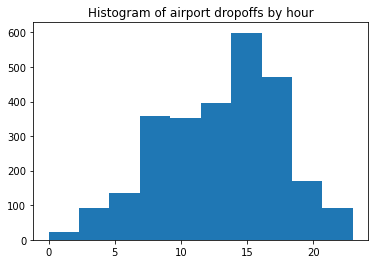

```python
# Visualize dropoffs by hour
airport_dropoffs = taxi_rides_merged.loc[taxi_rides_merged["DOLocationID"].isin(airports)]
plt.hist(airport_dropoffs["lpep_dropoff_hour"])
plt.title("Histogram of airport dropoffs by hour")
```

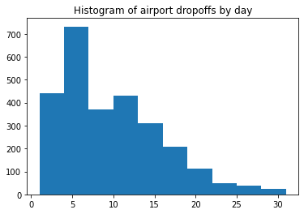

```python
# Visualize dropoffs by day
airport_trips["lpep_dropoff_date"] = airport_trips["lpep_dropoff_datetime"].apply(lambda x: x.day)
plt.hist(airport_trips["lpep_dropoff_date"])
plt.title("Histogram of airport dropoffs by day")
```

## Part 5

The code blocks below train a gradient boosting regression model to predict tip percentage. We do not have demographic information for all the taxi zones, so I drop rows with missing demographic information.

```python
# Create a tip percentage variable and drop the correlated columns
taxi_rides_merged["tip_percentage"] = taxi_rides_merged["tip_amount"] / taxi_rides_merged["fare_amount"]
```

```python
taxi_rides_merged.ehail_fee.unique() # E-Hail fee is none throughout, so drop it. Also drop the NTA Codes and datetime fields

# Drop the zone columns
taxi_rides_ml = taxi_rides_merged.drop(columns = ["Taxi zone_PU", "Taxi zone_DO", "tip_amount", "fare_amount"], axis = 1)

# One-hot encode the type, flag, and ID columns
taxi_rides_ml = pd.get_dummies(taxi_rides_ml, columns = ["store_and_fwd_flag", "VendorID", "RatecodeID", "payment_type", "trip_type"], drop_first = True)

# Remove any remaining object/datetime columns
taxi_rides_ml = taxi_rides_ml.select_dtypes(exclude = ["object", "datetime"])
taxi_rides_ml.head()
```

|  | PULocationID | DOLocationID | passenger_count | trip_distance | extra | mta_tax | tolls_amount | improvement_surcharge | total_amount | congestion_surcharge | TotalPop_PU | Female_PU | Hispanic_PU | WhiteNonHisp_PU | BlackNonHisp_PU | AsianPI_PU | OtherRace_PU | TotalPop_DO | Female_DO | Hispanic_DO | WhiteNonHisp_DO | BlackNonHisp_DO | AsianPI_DO | OtherRace_DO | lpep_pickup_hour | lpep_pickup_day_of_wk | lpep_dropoff_hour | lpep_dropoff_day_of_wk | tip_percentage | … |
| --- | --- | --- | --- | --- | --- | --- | --- | --- | --- | --- | --- | --- | --- | --- | --- | --- | --- | --- | --- | --- | --- | --- | --- | --- | --- | --- | --- | --- | --- | --- |
| 0 | 41 | 13 | 1.0 | 8.24 | 0.5 | 0.5 | 0.0 | 0.3 | 38.19 | 2.75 | 48596.0 | 54.4 | 19.7 | 18.7 | 54.9 | 4.2 | 2.6 | NaN | NaN | NaN | NaN | NaN | NaN | NaN | 0 | 6 | 0 | 6 | 0.288302 | … |
| 1 | 181 | 107 | 1.0 | 4.87 | 0.5 | 0.5 | 0.0 | 0.3 | 25.05 | 2.75 | 74526.0 | 51.9 | 18.5 | 65.1 | 5.2 | 6.7 | 4.6 | 27396.0 | 55.6 | 7.0 | 73.0 | 4.0 | 12.8 | 3.2 | 0 | 6 | 0 | 6 | 0.000000 | … |
| 2 | 41 | 166 | 1.0 | 0.69 | 0.5 | 0.5 | 0.0 | 0.3 | 6.30 | 0.00 | 48596.0 | 54.4 | 19.7 | 18.7 | 54.9 | 4.2 | 2.6 | 55450.0 | 55.1 | 22.1 | 47.7 | 11.5 | 15.2 | 3.5 | 0 | 6 | 0 | 6 | 0.000000 | … |
| 3 | 129 | 7 | 1.0 | 1.80 | 0.5 | 0.5 | 0.0 | 0.3 | 10.30 | 0.00 | 105083.0 | 49.8 | 55.3 | 16.1 | 1.8 | 24.0 | 2.8 | 77095.0 | 50.0 | 27.5 | 51.4 | 4.6 | 14.0 | 2.5 | 0 | 6 | 0 | 6 | 0.000000 | … |
| 4 | 74 | 152 | 1.0 | 1.25 | 0.5 | 0.5 | 0.0 | 0.3 | 10.79 | 0.00 | NaN | NaN | NaN | NaN | NaN | NaN | NaN | 23155.0 | 52.5 | 56.7 | 9.7 | 28.0 | 3.1 | 2.5 | 0 | 6 | 0 | 6 | 0.355714 | … |

```python
# Run and evaluate a very basic gradient boosting regressor

# Drop missing values, leaving roughly half the records. Because we explicitly want to investigate demographic information in the next section, I do not want to impute demographic
    # information and potentially introduce misleading data to the dataset.
taxi_rides_ml = taxi_rides_ml.dropna()
taxi_rides_ml.shape

taxi_rides_ml = taxi_rides_ml.sample(frac = 1) # shuffle the dataset to ensure the algorithm is not merely memorizing the data
X, y = taxi_rides_ml.drop(columns = ["tip_percentage"], axis = 1), taxi_rides_ml[["tip_percentage"]]

X_train, X_test, y_train, y_test = train_test_split(X, y, train_size = 0.7, random_state=123)

estimator = GradientBoostingRegressor(n_estimators = 250, random_state=123)

estimator.fit(X_train, y_train)

y_pred = estimator.predict(X_test)

print(f"The baseline model's R2 score is {r2_score(y_test, y_pred)} and its mean absolute error is {mean_absolute_error(y_test, y_pred)}.")
```

```
The baseline model's R2 score is 0.14300349783595934 and its mean absolute error is 0.05548933101983181.
```

## Part 6

The next code chunks evaluate the results by pickup and dropoff location demographics. I look first at the distribution of the black and nonwhite population in pickup and dropoff zones. Then, I set a threshold where the population rates are greater than the median. I analyze the average tip percentage and model error above and below this threshold. The results appear to show that predicted tip percentages in general are lower in zones with Black and Hispanic population rates that are higher than the median. Additionally, the mean absolute error is higher for high-Black population pickup zones.

```python
# Set up thresholds (at equal to or greater than the median)
comparison_dataset = X_test.copy()

comparison_dataset["BlackPU_Threshold"] = np.where(comparison_dataset["BlackNonHisp_PU"] >= comparison_dataset["BlackNonHisp_PU"].median(), 1, 0)
comparison_dataset["HispanicPU_Threshold"] = np.where(comparison_dataset["Hispanic_PU"] >= comparison_dataset["Hispanic_PU"].median(), 1, 0)
comparison_dataset["HispanicDO_Threshold"] = np.where(comparison_dataset["Hispanic_DO"] >= comparison_dataset["Hispanic_DO"].median(), 1, 0)
comparison_dataset["BlackDO_Threshold"] = np.where(comparison_dataset["BlackNonHisp_DO"] >= comparison_dataset["BlackNonHisp_DO"].median(), 1, 0)

# Merge predictions and calculate MAE for each row
taxi_rides_ml_merged = pd.concat([comparison_dataset.reset_index(drop=True), y_test.reset_index(drop = True), pd.DataFrame({"predicted_tip_pct": y_pred})], axis = 1)

taxi_rides_ml_merged["mae"] = taxi_rides_ml_merged.apply(lambda row: mean_absolute_error([row.tip_percentage], [row.predicted_tip_pct] ), axis = 1)
```

```python
# Show the Mean Absolute Error for the zones where the Black and Hispanic population rates are greater than the 75th percentile.

mae_bPU = mean_absolute_error(y_true = taxi_rides_ml_merged.loc[taxi_rides_ml_merged["BlackPU_Threshold"] == 1, "tip_percentage"], y_pred = taxi_rides_ml_merged.loc[taxi_rides_ml_merged["BlackPU_Threshold"] == 1, "predicted_tip_pct"] )
mae_bDO = mean_absolute_error(y_true = taxi_rides_ml_merged.loc[taxi_rides_ml_merged["BlackDO_Threshold"] == 1, "tip_percentage"], y_pred = taxi_rides_ml_merged.loc[taxi_rides_ml_merged["BlackDO_Threshold"] == 1, "predicted_tip_pct"] )

print(f"The MAE for high-Black population pickup zones is {np.round(mae_bPU, 3)} and for dropoff zones is {np.round(mae_bDO, 3)}.")

mae_hPU = mean_absolute_error(y_true = taxi_rides_ml_merged.loc[taxi_rides_ml_merged["HispanicPU_Threshold"] == 1, "tip_percentage"], y_pred = taxi_rides_ml_merged.loc[taxi_rides_ml_merged["HispanicPU_Threshold"] == 1, "predicted_tip_pct"] )
mae_hDO = mean_absolute_error(y_true = taxi_rides_ml_merged.loc[taxi_rides_ml_merged["HispanicDO_Threshold"] == 1, "tip_percentage"], y_pred = taxi_rides_ml_merged.loc[taxi_rides_ml_merged["HispanicDO_Threshold"] == 1, "predicted_tip_pct"] )

print(f"The MAE for high-Hispanic population pickup zones is {np.round(mae_hPU, 3)} and for dropoff zones is {np.round(mae_hDO, 3)}.")
```

```
The MAE for high-Black population pickup zones is 0.065 and for dropoff zones is 0.064.
The MAE for high-Hispanic population pickup zones is 0.055 and for dropoff zones is 0.053.
```

```python
# Show the difference in predicted fares across subgroups

tip_bPU = taxi_rides_ml_merged.loc[taxi_rides_ml_merged["BlackPU_Threshold"] == 1, "predicted_tip_pct"].mean()
tip_bDO = taxi_rides_ml_merged.loc[taxi_rides_ml_merged["BlackDO_Threshold"] == 1, "predicted_tip_pct"].mean()

print(f"The average predicted tip percentage for high-Black population pickup zones is {np.round(tip_bPU, 3)} and for dropoff zones is {np.round(tip_bDO, 3)}. In contrast, the average predicted tip percentage across all zones is {np.round(y_pred.mean(), 3)}.")

tip_hPU = taxi_rides_ml_merged.loc[taxi_rides_ml_merged["HispanicPU_Threshold"] == 1, "predicted_tip_pct"].mean()
tip_hDO = taxi_rides_ml_merged.loc[taxi_rides_ml_merged["HispanicDO_Threshold"] == 1, "predicted_tip_pct"].mean()

print(f"The average predicted tip percentage for high-Hispanic population pickup zones is {np.round(tip_hPU, 3)} and for dropoff zones is {np.round(tip_hDO, 3)}. In contrast, the average predicted tip percentage across all zones is {np.round(y_pred.mean(), 3)}.")
```

```
The average predicted tip percentage for high-Black population pickup zones is 0.098 and for dropoff zones is 0.084. In contrast, the average predicted tip percentage across all zones is 0.1.
The average predicted tip percentage for high-Hispanic population pickup zones is 0.085 and for dropoff zones is 0.078. In contrast, the average predicted tip percentage across all zones is 0.1.
```